# HAR assignment

PJ

April 17, 2016

The Human Activity Recognition dataset contains some excellent data of people exercising with Dumbbells. More details about the data are available on this website: http://groupware.les.inf.puc-rio.br/har

The following brief report explains how a simple random forest model was created using this data.

The training data for this project are available here: https://d396qusza40orc.cloudfront.net/predmachlearn/pml-training.csv

The test data are available here: https://d396qusza40orc.cloudfront.net/predmachlearn/pml-testing.csv

```r
library(caret)
training <- read.csv("./pml-training.csv",
                     stringsAsFactors=T)
inTrain <- createDataPartition(training$classe, p=0.7)[[1]]
t <- training[inTrain,]
v <- training[-inTrain,]
testing <- read.csv("pml-testing.csv", stringsAsFactors = T)
```

# Exploratory Analysis

```r
library(ggplot2)
View(t)
# summary(t)
```

After looking at the data table and summary information, I evaluated which variables commonly contained numerical data and realized that the most reliable variables were the roll,pitch and yaw data from each of the three location - belt, arm and dumbbell. Most of the other variables contain lots of missing and NAN data, so they wouldn’t be immediately useful for training the model without pre-processing the data.

I looked at particular variables for easy trends like: 1) Was particular individuals asked to do only certain types of exercise classes. 2) Was there a sequence followed that might be reflected in the timestamp data.

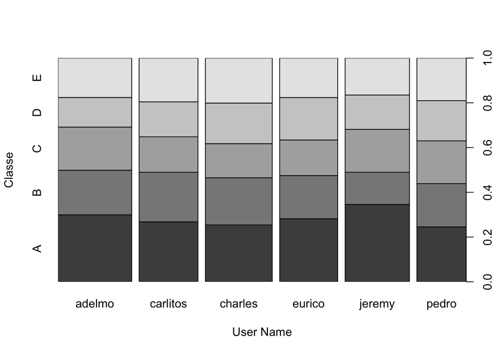

```r
plot(training$user_name,training$classe, xlab="User Name", ylab = "Classe")
```

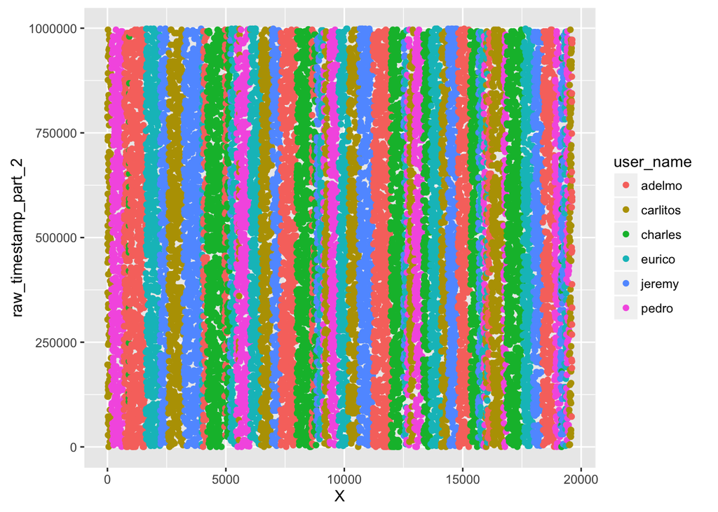

```r
qplot(X,raw_timestamp_part_2,color=user_name, data =training)
```

# Model Building

Armed with this information, I decided to try a simple random forest model, with cross-validation as follows.

```r
modrf <- train(classe ~ roll_belt + pitch_belt + yaw_belt + roll_arm + pitch_arm + yaw_arm + roll_dumbbell + pitch_dumbbell + yaw_dumbbell, data = t, method = "rf",trControl = trainControl(method = "cv", number = 3))
modrf
```

[output not shown]

As you can see, the accuracy of the model is predicted to be as high as 95%. # Validation

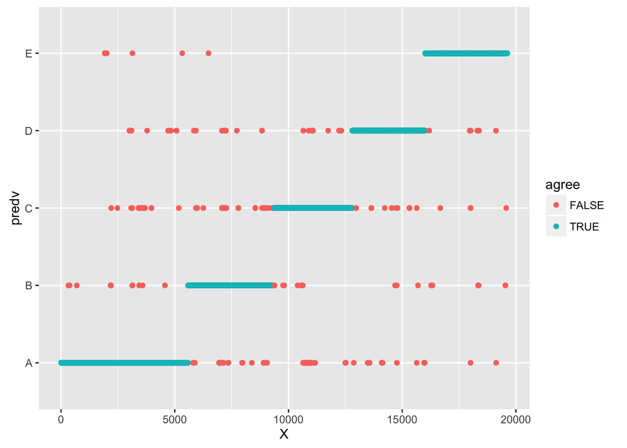

```r
predv <- predict(modrf, v)
agree <- predv == v$classe
v <- cbind(v, predv,agree)
qplot(X,predv, color = agree, data = v)
```

As shown by the scatter plot, the model works very well on the validation data.

# Prediction

Using this model, we can predict the classe variable for the testing dataset.

```r
results <- predict(modrf, testing)
results
```

```
##  [1] B A B A A E D B A A B C B A E E A B B B
## Levels: A B C D E
```